# Capstone Project Milestone Report

Douglas Thoms

November 2, 2019

## Goals of App and Algorithm

### Algorithm

- Predict a set of words (up to 4 words) using a preceding set of words (up to 4 words)

### App

- The app will take the last 4 words of the sentence and use the algorithm to predict the most likely set of following words
- The app and data will be small enough to post to the shinyapps.io website document (less than 1GB)

## Feature of App and Algorithm

### Algorithm

- The algorithm will initially use the smart back-off model since it is easy to code, simple and known to be effective
- May also try the knesey-ney model if appropriate,

### App

- User will input a sentence into an input field
- A warning will be generated by app if the most recent word has no corresponding observed bi-gram in the data,
- App will add the prediction to the end of the input if algorithm creates a prediction,

## Plan to Create Model and App

1. Download data
2. Sample Data
3. Conduct preliminary Exploratory Data Analysis
4. Research word prediction models and choose potential models
5. Construct Model
6. Quality check model
7. Optimize model to operate on shinyapps.io model
8. Create presentation

## Summary of Basic Dataset Features

- Source of Data - https://d396qusza40orc.cloudfront.net/dsscapstone/dataset/Coursera-SwiftKey.zip, from SwiftKey
- Collection of English language news, blogs and tweets from internet (foreign words, number, slang and non-words may be included)
- Data is raw so punctuation and unnecessary words will need to be removed

  | Data File name | # of Lines |
  | --- | --- |
  | en_US.blogs.txt | 899,289 |
  | en_US.news.txt | 1,010,274 |
  | en_US.twitter.txt | 2,360,149 |
  | ——————- | ————- |

- Too much data for computer to process so data will need to be randomly sampled - around 20,000 lines per source was taken
- The number of tokens in the sample was calculated as 1033046.
- The number of features(kinds of words) in the sample is 29658 before the n-grams (combinations of words) were created.
- A total of 47363 lines were in the sample.
- Word count was calculated after tokenizing the data, using regular expressions to remove non-words like website addresses, numbers and profane words

## Exploratory Data Analysis

### Wordcloud of Top Features

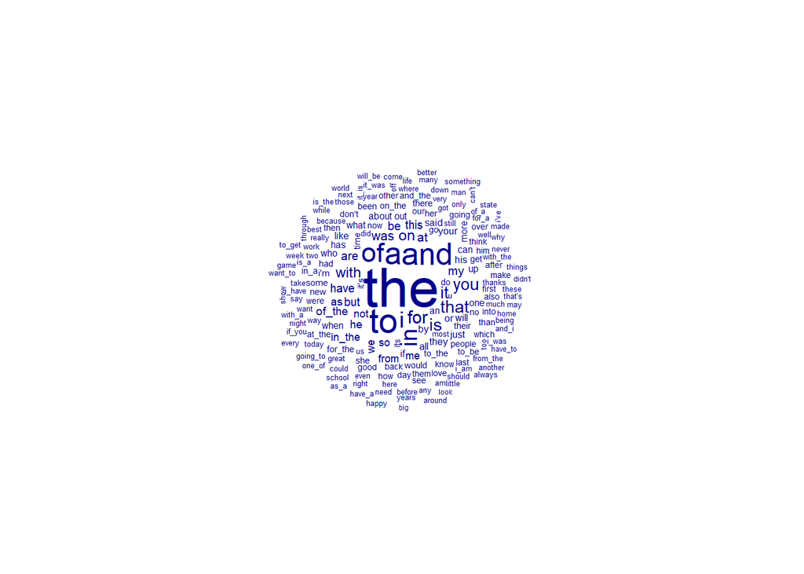

No stop words have been removed and as a result, stop words dominate the word cloud. Stop words are very common words in English that dominate the language like “a”,“the”, and “and”. This is expected and stop words will be initially used in the data sample since the next word could very well be a stop word like “a”, “the”, “and”, “he” and “she”."

### Distribution of Words

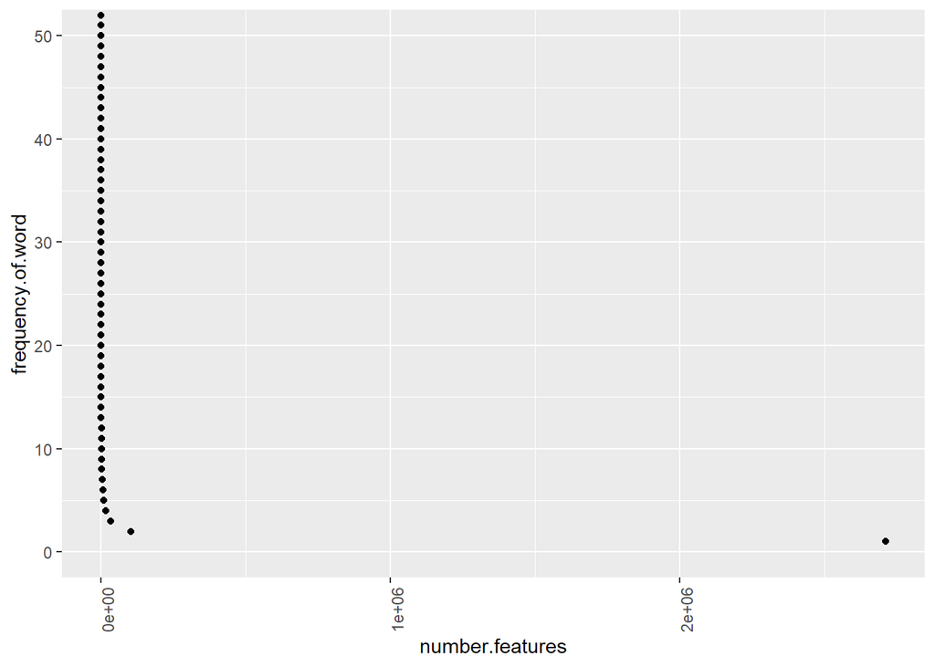

This graph shows the number of features with a frequency of 50 or lower. It shows that the vast majority of features only appear once. This includes n-grams up to 5-grams so a lot these might be higher order n-grams. Still it suggests there will need to be a trade-off between a comprehensive vocabulary for the model and a manageable vocabulary size that both the computer and shinyapps.io website can handle.

### Number of Features Needed to Capture All Words

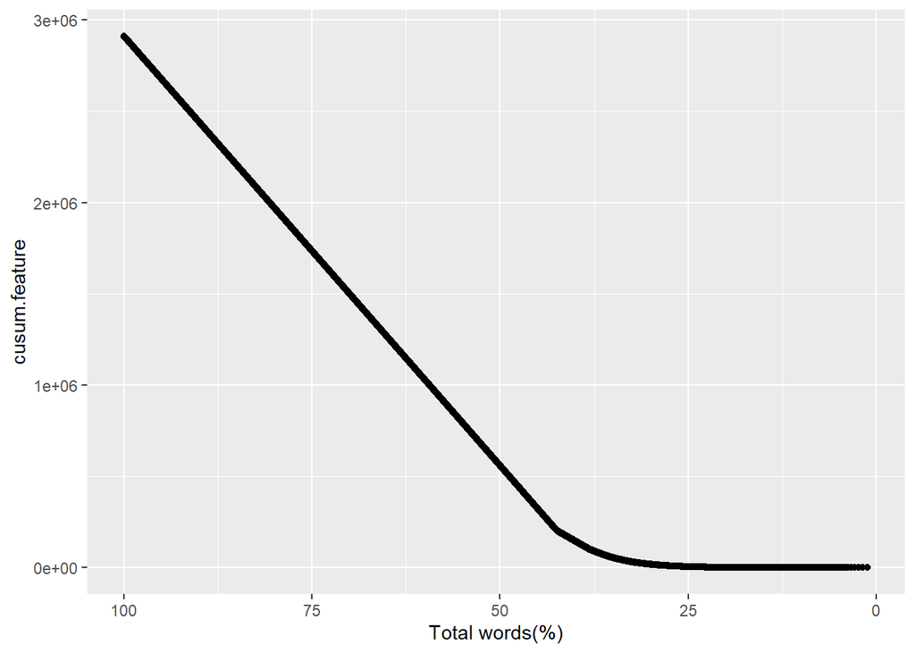

This graph further suggests there will need to be a trade-off between coverage of features and the size of the vocabulary. We will need about 500,000 features to cover 50% of the total words and about 2.6 million to cover 95% of words in the sample.

## Findings

- Initially, I aimed to have a 95% confidence level that the sample is representative of the population - this was calculated as approximately 664 lines each from the news, blogs and tweets corpuses - the sample was increased to around 2000 lines per corpus
- However, the number of features(different kind of words) increased significantly (a ratio of 86.9) when around 20,000 lines per corpus was used - this suggests a larger sample is needed

## Recommended Actions

- Factors to augment when creating model
  - size of data sample
  - experiment with excluding stop words to lower vocabulary size
  - experiment with model used in algorithm
  - experiment with refining words with dictionaries
  - potentially remove words with lower frequency to make vocabulary size more manageable

## Feedback Appreciated

Any feedback or thoughts are appreciated.